# R Notebook

Example2: Keeping data based on a certain condition mtcar_sub2<-subset(mtcars, mpg > 20) titanic_sub1<-subset(Titanic, Sex == “Male”)

```r
mtcar_sub<- subset(mtcars, select = c(mpg,wt,hp))
#this being able the extract only these values from the data sheet
```

Example2: Keeping data based on a certain condition

```r
mtcar_sub2<-subset(mtcars, mpg > 20)
```

```r
View(Titanic)
#titanic_sub1 <- subset(Titanic, Sex == "Male") not working....
```

Renaming columns Install gdata - install.packages(“gdata”)

Example: How can we change the name of mpg and wt in mtcars_sub to something else?

rename.vars(mtcar_sub, c(‘mpg’,‘wt’), c(‘newtext1’,‘newtext2’))

```r
library(gdata)
rename.vars(mtcar_sub, c('mpg','wt'), c('mpg_new','wt_new'))
```

Current DateTime

```r
Sys.Date()
Sys.time()
date()
```

use strptime() to convert date formats. Example: x <- “04/09/2021” newtime <- strptime(x, “%d/%m/%Y”)

```r
x <- "04/09/2021"
newtime <- strptime(x, "%d/%m/%Y")
print(newtime)
```

use difftime() to find the difference between two dates/times

```r
difftime(newtime, Sys.Date(), units = 'weeks')
```

Sorting Data

Use the order() function :P Example: sort mtcar_sub2 by mpg, then wt.

```r
mtcar_sub2_sorted <- mtcar_sub2[order(mtcar_sub2$mpg, - mtcar_sub2$wt), ] # the - makes descending order

#mtcar_sub2_sorted <- mtcar_sub2[order(mtcar_sub2$mpg, mtcar_sub2$wt), ] Ascending order
```

Advanced graphs Hexbin Used as an alternative scatterplot. Good when there are a lot of overlapping values

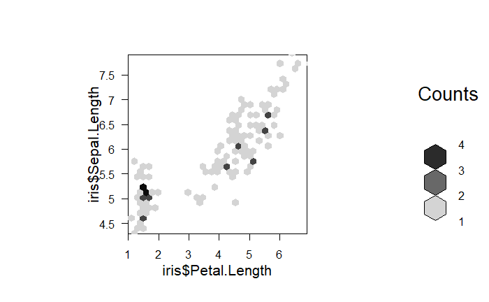

```r
library(hexbin)
myhexb<-hexbin(iris$Petal.Length, iris$Sepal.Length, xbins=30)
plot(myhexb)
```

```r
View(iris)
```

Mosaicplot Used for observing categorical data. The area represents the number of observations:

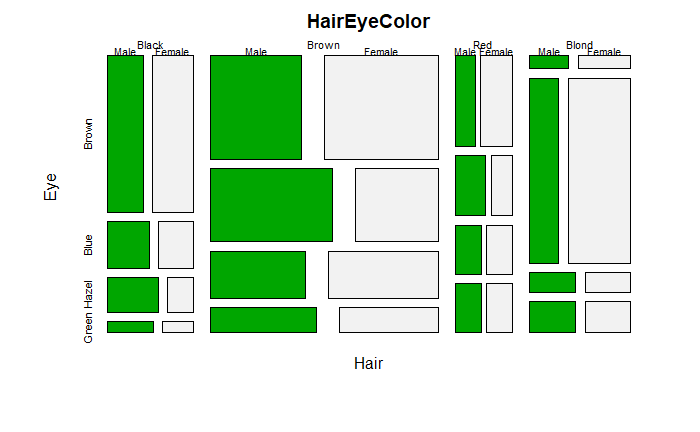

```r
mosaicplot(HairEyeColor, col=terrain.colors(2))
```

Heatmap Used to compare several categorical values and how they perform relative to many numerical values.

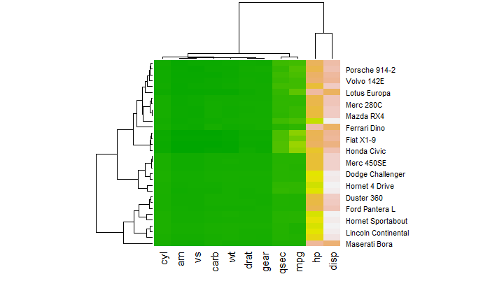

```r
data(mtcars)
htmap <-as.matrix(mtcars)
heatmap(htmap, col=terrain.colors(256))
```

3d Graphs 3D scatterplot #Install Rcmdr

```r
library(Rcmdr)
data(iris)
scatter3d(iris[,1],iris[,2],iris[,3])
```

R commander GUI

Install rpl first If you need to restart R Commander: detach(“package:Rcmdr”, unload = TRUE) library(“Rcmdr”) How can we do the 3D graph we just did through the GUI? Use Petal.Length as the response variable and Sepal Length and Width as the explanatory variables.

```r
library(Rcmdr)
detach("package:Rcmdr", unload = TRUE)
```

WORD CLOUDS

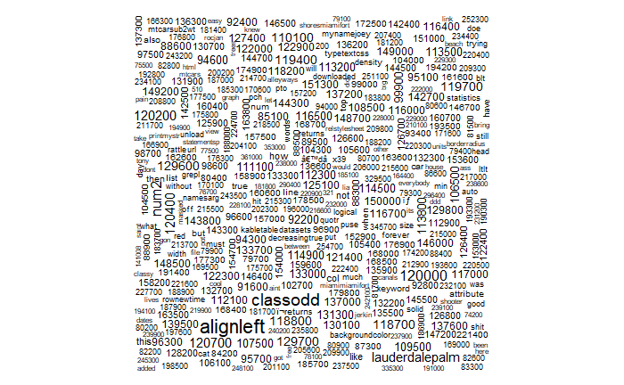

```r
library(tm)
library(wordcloud)
mlktxt<-"C:\\Users\\kyle1\\Documents\\GitHub\\R-Projects\\RData\\R-StudyGuide"
b<-Corpus(DirSource(mlktxt), readerControl = list(language = "eng"))
b<-tm_map(b, tolower)
b<-tm_map(b, stripWhitespace)
b<- tm_map(b, removePunctuation)
tdm<-TermDocumentMatrix(b)
m1<-as.matrix(tdm)
v1<-sort(rowSums(m1), decreasing=TRUE)
d1<-data.frame(word = names(v1), freq=v1)
wordcloud(d1$word,d1$freq)
```

```r
#YOU CAN ADD AS MUCH TXT FILES TO COMBINE AS YOU WANT
#THIS WILL BE IN THE ASSIGNMENT
```

```r
library(ggplot2)

ggplot(GHCND_sample_csv) +
 aes(x = DATE, y = TMAX) +
 geom_line(size = 1L, colour = "#0c4c8a") +
 labs(title = "TEMP OVER TIME") +
 theme_minimal()
```

First – A follow up on Wordcloud Filtering #this is on mac!!!!!!!!!!!!!!!!!!!!!!!!!!!!!!

```r
library(tm)
library(wordcloud)
mlktxt<-"/Users/kyle/R FOLDER/R Projects/wordcloud"
b<-Corpus(DirSource(mlktxt), readerControl = list(language = "eng"))
b<-tm_map(b, tolower)
b<-tm_map(b, stripWhitespace)
b<- tm_map(b, removeWords, stopwords("english")) # this take out the common words
b<- tm_map(b, removeWords, c("just", "way"))
b<- tm_map(b, removePunctuation)
tdm<-TermDocumentMatrix(b)
m1<-as.matrix(tdm)
v1<-sort(rowSums(m1), decreasing=TRUE)
d1<-data.frame(word = names(v1), freq=v1)
wordcloud(d1$word,d1$freq, min.freq = 5, max.words = 25, col=rainbow(4))
```

how to find path on mac

```r
getwd()
```

```r
stopwords("english")
```

Radiant Web based GUI To install: install.packages(“radiant”, repos = “https://radiant-rstats.github.io/minicran/”, type = ‘binary’) To run click on “Addins” and “Start radiant” How can we do some of the things we have seen in Radiant? Note: You must stop Radiant before you are able to run more code in RStudio. —————————————————————————–

Esquisse

Another great GUI for building graphs Uses “shiny” package as well. To install: install.packages(“esquisse”)

How can we build graphs with the Esquisse GUI?

[output not shown]

Installing/Running Rattle

Run the following in the console: install.packages(“rattle”, dependencies=c(“Depends”, “Suggests”))

Grab a cup of coffee :P (Install takes about 5-10 mins, lots of packages to install)

Once installed run the following code to start the GUI: library(rattle) rattle() Note: you may need to install GTK+ and Restart R after it is installed.

```r
ytemp <-4 #same shit

5 -> ytemp #same shit


print(ytemp) #same shit
ytemp        #same shit

# know the type in R
print(class(ytemp))

as.character(ytemp)
```

```python
y = str('2')
print(y)
```